# Stan applied

Jeffrey Chrabaszcz  
17 January 2014

### References

[figure not shown]

### Outline

1. LASSO
2. Ridge regression
3. Elastic net
4. Multiple predictors in stan
5. Applied example

### LASSO

The *least absolute shrinkage and selection operator* tends to improve prediction, (and protect against Type S errors), by shrinking parameter estimates.

\[ \beta_j \sim Laplace(0, b_\epsilon) \]

\[ Laplace(x) = \frac{1}{2b}e^{-\frac{|x - \mu|}{b}} \]

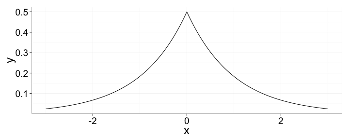

### Ridge regression & elastic net

At least two other shrinkage methods exist. **Ridge regression**, which shrinks \( \beta \) coefficients toward one another, and **elastic net**, which shrinks coefficients toward one another and toward zero at the same time.

This ends up being very easy to implement in MCMC.

```r
mu_b ~ double_exponential(0.0, 1.0);
b ~ normal(mu_b,1.0);
```

```r
parameters {
  real b0;
  vector[P] b;
  real mu_b;
  real<lower=0> tau;
  real<lower=0> nu;
}
transformed parameters {
  real<lower=0> sigma;
  sigma <- pow(tau, -0.5);
}
model {
  b0 ~ normal(0.0, 1.0);
  mu_b ~ double_exponential(0.0, 1.0);
  b ~ normal(mu_b,1.0);
  nu ~ exponential(df);
  tau ~ exponential(1);
  for (i in 1:N)
    y[i] ~ student_t(nu + 1, b0 + dot_product(x[i], b), sigma);
}
```

### Applied example

In cognitive and I/O psychology, we care a lot about predicting intelligence. We got a community sample with 247 individuals, all of whom completed the following tasks:

- Raven's advanced progressive matrices
- Shapebuilder
- Reading span
- Need for cognition

### Exploratory data analysis

```
     ravens           nfc            shape
 Min.   : 0.00   Min.   :-29.0   Min.   : 135
 1st Qu.: 7.00   1st Qu.: 13.5   1st Qu.: 972
 Median :10.00   Median : 26.0   Median :1225
 Mean   : 9.37   Mean   : 26.2   Mean   :1334
 3rd Qu.:12.00   3rd Qu.: 40.0   3rd Qu.:1638
 Max.   :17.00   Max.   : 72.0   Max.   :3065
```

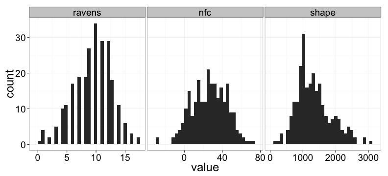

### Priors

Based on our goals and visualization, we can assume some things:

- Our outcome isn't normal!
- The goal is prediction, so we want to shrink our betas
- Motivation might compensate for WM in predicting IQ

Now we just have to specify these things.

### Stan model

```r
logit_code <- '
data {
  int<lower=0> N;
  int<lower=1> P;
  int<lower=2> K;
  int<lower=1,upper=K> y[N];
  row_vector[P] x[N];
}
parameters {
  vector[P] b;
  real mu_b;
  ordered[K-1] c;
}
model {
  mu_b ~ normal(0.0, 1.0);
  b ~ normal(mu_b, K/4.0);
  for (n in 1:N)
    y[n] ~ ordered_logistic(x[n] * b, c);
}
'
```

### Stan data

```r
s.data <- b.data
s.data$ravens <- s.data$ravens + 1
s.data[,-1] <- as.data.frame(scale(s.data[,-1]))
s.data$shape.by.nfc <- s.data$nfc * s.data$shape

logit_dat <- list(y = s.data[,1],
                 x = s.data[,-1],
                 N = nrow(s.data),
                 P = ncol(s.data) - 1,
                 K = length(unique(s.data[,1]))
)

l.posterior <- stan(model_code = logit_code, data = logit_dat, iter = 1000, chains = 3)
```

### Ordered logistic results

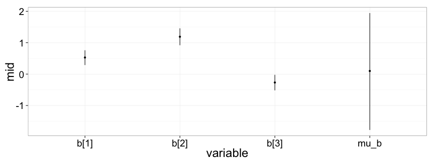

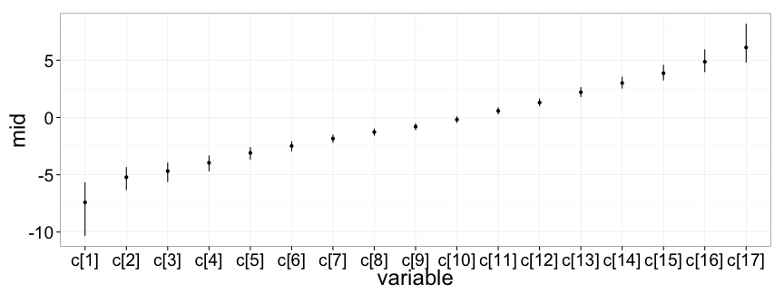

### Diagnostics (betas)

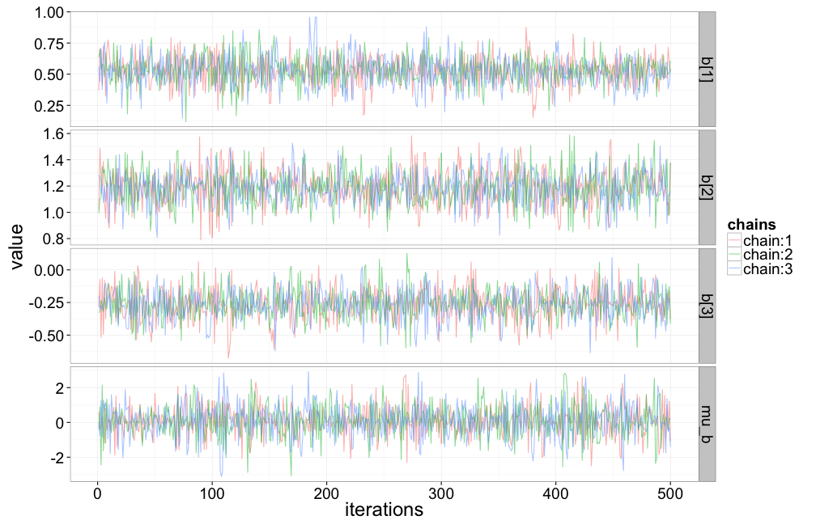

### Diagnostics (cuts)

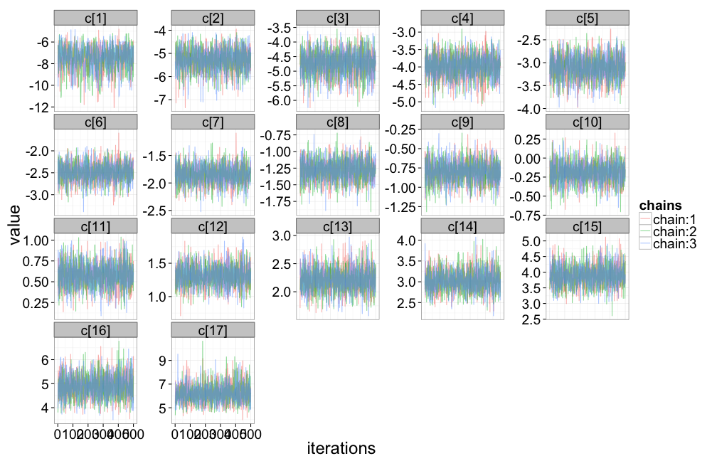